# 2016 Pteropod Water Chem

Shelly Trigg  
3/19/2019

load libraries

read in and format spec data

```r
#define salinity data path
spec_path <- "~/Documents/GitHub/Seawater-Chemistry-Analysis/2016-17_PteropodExp_WaterChem/PteropodWaterChem/specs_w_correction/"
#salinity is recorded as 29.62 for all dates
#PMEL measured salinity 29.61
##I manually changed the data sheets to reflect the salinity average: 28.94
#Salinity was measured on Nov 22 @ 28.27psu and on Nov 30 @ 29.61psu

#List all spec files in directory
file.names <- dir(spec_path, pattern = ".csv", full.names = TRUE)

#Create empty output file for new files to go into
Spec_pH <- data.frame()

#Create loop to go through all files and remove unnecessary columns
for (i in 1:length(file.names)){
  SpecTemp <- read.csv(file.names[i], stringsAsFactors = FALSE)
  SpecTemp2 <- SpecTemp[-1,-c(1,4,6,8,10:30)]

  Spec_pH <- rbind(Spec_pH,SpecTemp2)
}

#Make a list of MOATS numbers in order
moatsNames <- c(1,3,4,5,6,7,8,10,11,12,13)

#Rename columns
colnames(Spec_pH)[1:5]<-c("MOATS","Jar","Date","Salinity","pH")

#Make MOATS a factor, and pH numeric
Spec_pH$MOATS<-as.numeric(Spec_pH$MOATS, moatsNames)
Spec_pH$Salinity<- as.numeric(Spec_pH$Salinity)
Spec_pH$pH<-as.numeric(Spec_pH$pH)

#remove empty rows
Spec_pH <- subset(Spec_pH, !is.na(pH))

#order rows by MOATS number
Spec_pH <- Spec_pH[order(Spec_pH$MOATS),]

#Change DateTime format so R is happy
str(Spec_pH)
```

```
## 'data.frame':    122 obs. of  5 variables:
##  $ MOATS   : num  1 1 1 1 1 1 1 1 2 2 ...
##  $ Jar     : chr  "C7" "" "" "" ...
##  $ Date    : chr  "22-Nov-16" "24-Nov-16" "24-Nov-16" "26-Nov-16" ...
##  $ Salinity: num  28.9 28.9 28.9 28.9 28.9 ...
##  $ pH      : num  7.4 7.46 7.46 7.37 7.39 ...
```

```r
Spec_pH$Date <- as.POSIXct(strptime(Spec_pH$Date, "%e-%b-%y"))

#Add treatment column
lowMOATS <- c(1,4,5,8,10,11)
Spec_pH$Treatment <- "High"
Spec_pH$Treatment[Spec_pH$MOATS %in%lowMOATS] <- "Low"
colnames(Spec_pH)[5] <- "pH_at_25C"
Spec_pH$Data_Type <- "Spec"
```

read in and format MOATS data

```r
#define path to master MOATS data folder containing all individual MOATS folders (i.e. M1-M13) each with a set of .lvm files
lvm_path <- "~/Documents/GitHub/Seawater-Chemistry-Analysis/2016-17_PteropodExp_WaterChem/PteropodWaterChem/MOATS_data"
#create empty dataframe
d <- data.frame()
#get the folder list from the wd
folder.list <- dir(lvm_path, full.names = TRUE)
#this sets the window length (number of samples to average for subsampled dataset)
winLen <- 100

#this will get the file names in each folder
for(i in 1:length(folder.list)){
  file.names <- dir(folder.list[i], pattern = ".lvm")
  for(j in 1:length(file.names)){
    print(paste(folder.list[i],file.names[j], sep = "/"))
    #start pulling in the data.
    #First count the max number of columns in the file
    ncols <- max(count.fields(paste(folder.list[i],file.names[j],sep="/"), sep = "\t"))
    #Read in data to get date and time data were collected
    dtemp <- read.table(paste(folder.list[i],file.names[j],sep="/"), sep="\t", skip = 9, nrows=2, header=FALSE, col.names = paste0("V", seq_len(ncols)), stringsAsFactors=FALSE, fill = TRUE)
    #fill = TRUE adds NAs to empty fields,col.names = paste0("V", seq_len(ncols))  makes the function consider all columns for adding NAs to

    #pull the date and time from these cell
    datetime = paste(dtemp[1,2],dtemp[2,2],sep = "_")
    #convert to posix
    datetime <- as.POSIXct(strptime(datetime, "%Y/%m/%d_%H:%M:%S"), tz = "GMT")
    #now read in the rest of the data
    dtemp <- read.table(paste(folder.list[i],file.names[j],sep="/"), sep="\t", skip = 22, header=FALSE, col.names = paste0("V", seq_len(ncols)), stringsAsFactors=FALSE, fill = TRUE,skipNul = TRUE)
    #only include data for seconds, pH, tempLowBox, tempHiBox, DO
    dtemp <- dtemp[,c(1,2,5,8,11)]
    #create MOATS column; extracts MOATS number from folder name (i.e. '1' gets extracted from M1 Data')
    dtemp$moats <- substr(folder.list[i],nchar(folder.list[i])-1,nchar(folder.list[i]))
    dtemp$moats <- gsub("m","",dtemp$moats)
    dtemp$moats <- as.numeric(dtemp$moats)
    #rename remaining columns
    colnames(dtemp) <- c("Secs","pH", "OL", "O","DO","MOATS")
    #create a column for date
    dtemp$datetime <- datetime + dtemp$Secs
    #this next loop creates the short dataset, averaging over winlen number of records; take the total number of data rows, divide by winLen, and round to nearest integer.
    sLen <- as.integer(nrow(dtemp)/winLen)
    #create shortened data frame
    dShort <-dtemp[1:sLen, ]
    dStartIndex <- 1
    dEndIndex <- winLen
    for (l in 1:sLen){
      dShort[l, ]<- dtemp[dStartIndex, ]
      #for seconds column, print the range of seconds the average is taken over
      #dShort[l,1]<- paste(as.integer(dtemp[dStartIndex,1]),as.integer(dtemp[dEndIndex,1]), sep = "-")
      dShort[l,c(2:5)] <- apply(dtemp[dStartIndex:dEndIndex,c(2:5)],2,mean)
      dStartIndex <- dStartIndex + winLen
      dEndIndex <- dEndIndex + winLen
    }
    d <- rbind(d, dShort)
  }
}
```

[output not shown]

[output cut: 162 more lines]

restrict MOATS data to dates of the experiment

```r
start_date <- as.POSIXct("2016/11/21_17:00:00", "%Y/%m/%d_%H:%M:%S", tz = "GMT")
end_date <- as.POSIXct("2016/11/30_14:00:00", "%Y/%m/%d_%H:%M:%S", tz = "GMT")

d <- d[which(d$datetime >= start_date & d$datetime <= end_date),]
```

remove faulty MOATS data (M2 and M9)

```r
d <- d[which(d$MOATS != 2 & d$MOATS !=9),]
```

plot MOATS pH data

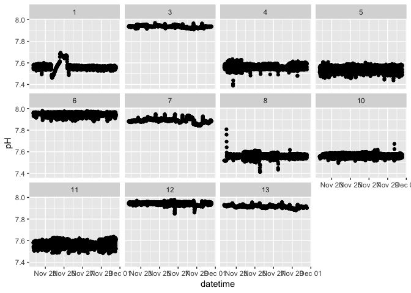

```r
#plot MOATS pH data
ggplot(d,aes(datetime, pH)) + geom_point() + facet_wrap(~MOATS)
```

blip on MOATS 1 between Nov 24-26; but could be real

plot MOATS temperature data

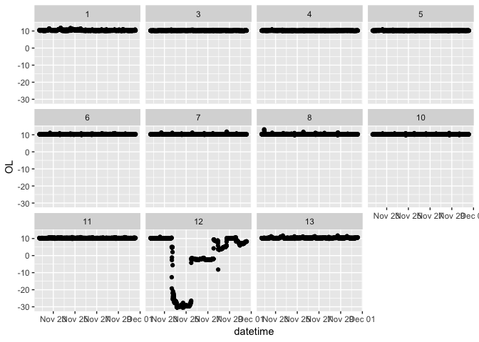

```r
#plot temp data for all MOATS
ggplot(d,aes(datetime, OL)) + geom_point() + facet_wrap(~MOATS)
```

MOATS 12 temp probe wonky, don't include that data when calculating averages

plot MOATS temperature data without MOATS 12 which seemed to have a wonky probe

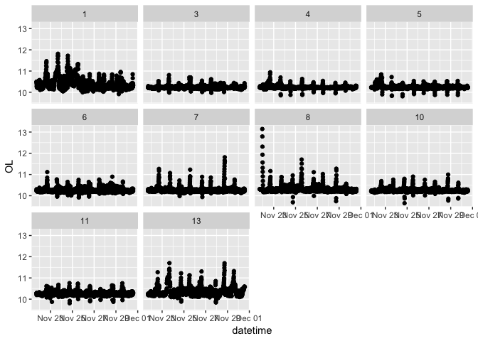

```r
#plot temp data without 12
ggplot(d[which(d$MOATS != 12),],aes(datetime, OL)) + geom_point() + facet_wrap(~MOATS)
```

all MOATS are a little spikey, suggesting these spikes are real

plot MOATS DO data

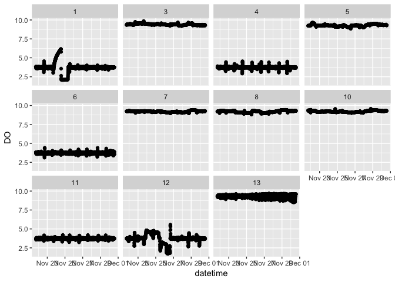

```r
ggplot(d,aes(datetime, DO)) + geom_point() + facet_wrap(~MOATS)
```

calculate mean temp

```r
mean(d[which(d$MOATS != 12),"OL"])
```

```
## [1] 10.28974
```

```r
#[1] 10.29312
sd(d[which(d$MOATS != 12),"OL"])
```

```
## [1] 0.1612368
```

```r
#[1] 0.165076
meanT <- mean(d[which(d$MOATS != 12),"OL"])
```

```r
for (i in 1:nrow(Spec_pH)){
  print(i)
  Sal <- 28.94
  #calculate TA ('alk') using the slope and intercept determined by 'Alkalinity v Salinity_KD_2018.R' script. This script compared Fassbender et al 2016 data to data from Muk (Chase's and our data from the past two years). This way, we were able to figure out what our offset is here at Muk.
  TAcalc <- ((50.946 * Sal)+522.506)/1000000
  pHspec <- Spec_pH$pH_at_25C[i]
  Temp <- meanT
  Spec_pH$carbSpecDIC[i] <- carb(flag = 8, pHspec, TAcalc, Sal,T=25)$DIC
  Spec_pH$carbSpecpH[i] <- carb(flag = 15, TAcalc,as.numeric(Spec_pH$carbSpecDIC[i]), Sal,Temp)$pH
  Spec_pH$carbSpecArag[i] <- carb(flag = 15, TAcalc,as.numeric(Spec_pH$carbSpecDIC[i]), Sal,Temp)$OmegaAragonite
}
```

[output not shown]

[output cut: 107 more lines]

```r
class(Spec_pH$carbSpecpH) <- "numeric"
class(Spec_pH$carbSpecDIC) <- "numeric"
Spec_pH$carbSpecDIC <- Spec_pH$carbSpecDIC *1000000
```

plot spec pH over time

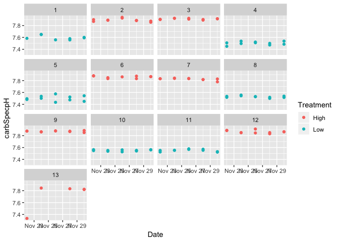

```r
ggplot(Spec_pH, aes(Date,carbSpecpH)) + geom_point(aes(color = Treatment)) + facet_wrap(~MOATS)
```

the Nov 22 spec pH for MOATS 13 seems very off; probably can exclude that

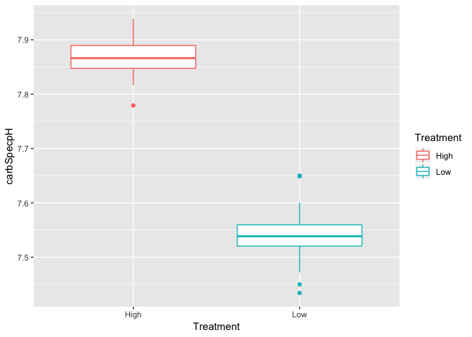

```r
ggplot(Spec_pH[which(Spec_pH$MOATS !=13 & Spec_pH$Date != as.POSIXct("2016-11-22")),]) + geom_boxplot(aes(Treatment,carbSpecpH, color = Treatment))
```

Calculate mean and sd for Spec pH

```r
mean(Spec_pH[which(Spec_pH$MOATS !=13 & Spec_pH$Date != as.POSIXct("2016-11-22") & Spec_pH$Treatment == "Low"),"carbSpecpH"])
```

```
## [1] 7.53927
```

```r
sd(Spec_pH[which(Spec_pH$MOATS !=13 & Spec_pH$Date != as.POSIXct("2016-11-22") & Spec_pH$Treatment == "Low"),"carbSpecpH"])
```

```
## [1] 0.04189884
```

```r
mean(Spec_pH[which(Spec_pH$MOATS !=13 & Spec_pH$Date != as.POSIXct("2016-11-22") & Spec_pH$Treatment == "High"),"carbSpecpH"])
```

```
## [1] 7.869221
```

```r
sd(Spec_pH[which(Spec_pH$MOATS !=13 & Spec_pH$Date != as.POSIXct("2016-11-22") & Spec_pH$Treatment == "High"),"carbSpecpH"])
```

```
## [1] 0.03409652
```

read in target treatment info and merge with MOATS data so data can be averaged by treatment

```r
treat <- read.csv("~/Documents/GitHub/Seawater-Chemistry-Analysis/2016-17_PteropodExp_WaterChem/PteropodWaterChem/Treatments.csv", stringsAsFactors = FALSE)
#merge treatment info with MOATS info
dtreat <- merge(d, treat, by = "MOATS", all.x = TRUE)
```

Calculate DO for each treatment I'm leaving in the blips in MOATS 1 and 12 because I don't know if they are real or not

```r
mean(dtreat[grep("HH", dtreat$Treatment_abbv),"DO"])
```

```
## [1] 9.309524
```

```r
sd(dtreat[grep("HH", dtreat$Treatment_abbv),"DO"])
```

```
## [1] 0.1571288
```

```r
mean(dtreat[grep("HL", dtreat$Treatment_abbv),"DO"])
```

```
## [1] 3.727524
```

```r
sd(dtreat[grep("HL", dtreat$Treatment_abbv),"DO"])
```

```
## [1] 0.4152265
```

```r
mean(dtreat[grep("LH", dtreat$Treatment_abbv),"DO"])
```

```
## [1] 9.230277
```

```r
sd(dtreat[grep("LH", dtreat$Treatment_abbv),"DO"])
```

```
## [1] 0.1247294
```

```r
mean(dtreat[grep("LL", dtreat$Treatment_abbv),"DO"])
```

```
## [1] 3.729256
```

```r
sd(dtreat[grep("LL", dtreat$Treatment_abbv),"DO"])
```

```
## [1] 0.4192891
```

plot DO per treatment as boxplots

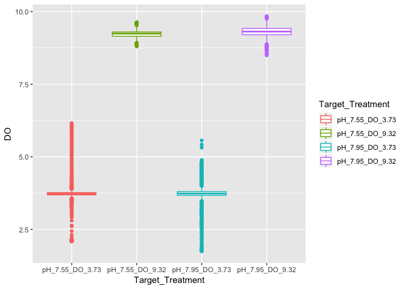

```r
ggplot(dtreat) + geom_boxplot(aes(Target_Treatment,DO, color = Target_Treatment))
```

```r
mean(dtreat[grep("HH", dtreat$Treatment_abbv),"pH"])
```

```
## [1] 7.914159
```

```r
sd(dtreat[grep("HH", dtreat$Treatment_abbv),"pH"])
```

```
## [1] 0.02343564
```

```r
mean(dtreat[grep("HL", dtreat$Treatment_abbv),"pH"])
```

```
## [1] 7.943158
```

```r
sd(dtreat[grep("HL", dtreat$Treatment_abbv),"pH"])
```

```
## [1] 0.01627819
```

```r
mean(dtreat[grep("LH", dtreat$Treatment_abbv),"pH"])
```

```
## [1] 7.551765
```

```r
sd(dtreat[grep("LH", dtreat$Treatment_abbv),"pH"])
```

```
## [1] 0.02731691
```

```r
mean(dtreat[grep("LL", dtreat$Treatment_abbv),"pH"])
```

```
## [1] 7.562677
```

```r
sd(dtreat[grep("LL", dtreat$Treatment_abbv),"pH"])
```

```
## [1] 0.03230692
```

plot pH per treatment as boxplots

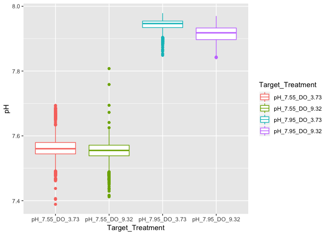

```r
ggplot(dtreat) + geom_boxplot(aes(Target_Treatment,pH, color= Target_Treatment))
```

read in presens data, merge with treatment info, remove faulty moats 2 and 9, calculate mean DO and SD for each treatment

```r
presens <- data.frame(read_xlsx("~/Documents/GitHub/Seawater-Chemistry-Analysis/2016-17_PteropodExp_WaterChem/PteropodWaterChem/Presens_Nov2016.xlsx"))
colnames(presens)[1] <- "MOATS"

presens <- merge(presens, treat, by = "MOATS")

#remove moats 2 and 9

presens <- presens[which(presens$MOATS != 2 & presens$MOATS != 9),]


###calculate average DO per treatment
mean(presens[which(presens$Treatment_abbv == "HH"),"PreSens.DO"])
```

```
## [1] 9.416667
```

```r
sd(presens[which(presens$Treatment_abbv == "HH"),"PreSens.DO"])
```

```
## [1] 0.2157159
```

```r
mean(presens[which(presens$Treatment_abbv == "HL"),"PreSens.DO"])
```

```
## [1] 3.875
```

```r
sd(presens[which(presens$Treatment_abbv == "HL"),"PreSens.DO"])
```

```
## [1] 0.6434672
```

```r
mean(presens[which(presens$Treatment_abbv == "LH"),"PreSens.DO"])
```

```
## [1] 9.846667
```

```r
sd(presens[which(presens$Treatment_abbv == "LH"),"PreSens.DO"])
```

```
## [1] 0.07234178
```

```r
mean(presens[which(presens$Treatment_abbv == "LL"),"PreSens.DO"])
```

```
## [1] 3.636667
```

```r
sd(presens[which(presens$Treatment_abbv == "LL"),"PreSens.DO"])
```

```
## [1] 0.1171893
```

make supplementary table

```r
#add column for jar so that Spec pH will stay in a separate row from MOATS data
dtreat$Jar <- "NA"
#make a column for time only
dtreat$time <- as.character(dtreat$datetime)
dtreat$time <- substr(dtreat$time,12,19)
#make a column for date only
dtreat$Date <- as.Date(dtreat$datetime)

#add treatment details to spec data
Spec_pH <- merge(Spec_pH, treat, by = "MOATS")

#merge MOATS data with Spec data
all_chem <- merge(dtreat,Spec_pH[,-grep("^Treatment$|Salinity|Data_Type|pH_at_25C", colnames(Spec_pH))], by = c("Date","MOATS", "Jar", "Target_Treatment", "Treatment_abbv"), all = TRUE)
```

Calculate average and sd Spec pH and Arag. sat.

```r
mean(all_chem[which(all_chem$MOATS !=13 & all_chem$Date != as.Date("2016-11-22") & all_chem$Treatment_abbv == "HH"),"carbSpecpH"], na.rm = TRUE)
```

```
## [1] 7.867579
```

```r
sd(all_chem[which(all_chem$MOATS !=13 & all_chem$Date != as.Date("2016-11-22") & all_chem$Treatment_abbv == "HH"),"carbSpecpH"], na.rm = TRUE)
```

```
## [1] 0.04821284
```

```r
mean(all_chem[which(all_chem$MOATS !=13 & all_chem$Date != as.Date("2016-11-22") & all_chem$Treatment_abbv == "HL"),"carbSpecpH"], na.rm = TRUE)
```

```
## [1] 7.86963
```

```r
sd(all_chem[which(all_chem$MOATS !=13 & all_chem$Date != as.Date("2016-11-22") & all_chem$Treatment_abbv == "HL"),"carbSpecpH"], na.rm = TRUE)
```

```
## [1] 0.02830754
```

```r
mean(all_chem[which(all_chem$MOATS !=13 & all_chem$Date != as.Date("2016-11-22") & all_chem$Treatment_abbv == "LH"),"carbSpecpH"], na.rm = TRUE)
```

```
## [1] 7.52778
```

```r
sd(all_chem[which(all_chem$MOATS !=13 & all_chem$Date != as.Date("2016-11-22") & all_chem$Treatment_abbv == "LH"),"carbSpecpH"], na.rm = TRUE)
```

```
## [1] 0.03492318
```

```r
mean(all_chem[which(all_chem$MOATS !=13 & all_chem$Date != as.Date("2016-11-22") & all_chem$Treatment_abbv == "LL"),"carbSpecpH"], na.rm = TRUE)
```

```
## [1] 7.551259
```

```r
sd(all_chem[which(all_chem$MOATS !=13 & all_chem$Date != as.Date("2016-11-22") & all_chem$Treatment_abbv == "LL"),"carbSpecpH"], na.rm = TRUE)
```

```
## [1] 0.04583957
```

```r
###arag. sat
mean(all_chem[which(all_chem$MOATS !=13 & all_chem$Date != as.Date("2016-11-22") & all_chem$Treatment_abbv == "HH"),"carbSpecArag"], na.rm = TRUE)
```

```
## [1] 1.109793
```

```r
sd(all_chem[which(all_chem$MOATS !=13 & all_chem$Date != as.Date("2016-11-22") & all_chem$Treatment_abbv == "HH"),"carbSpecArag"], na.rm = TRUE)
```

```
## [1] 0.1108779
```

```r
mean(all_chem[which(all_chem$MOATS !=13 & all_chem$Date != as.Date("2016-11-22") & all_chem$Treatment_abbv == "HL"),"carbSpecArag"], na.rm = TRUE)
```

```
## [1] 1.111505
```

```r
sd(all_chem[which(all_chem$MOATS !=13 & all_chem$Date != as.Date("2016-11-22") & all_chem$Treatment_abbv == "HL"),"carbSpecArag"], na.rm = TRUE)
```

```
## [1] 0.06736881
```

```r
mean(all_chem[which(all_chem$MOATS !=13 & all_chem$Date != as.Date("2016-11-22") & all_chem$Treatment_abbv == "LH"),"carbSpecArag"], na.rm = TRUE)
```

```
## [1] 0.5325763
```

```r
sd(all_chem[which(all_chem$MOATS !=13 & all_chem$Date != as.Date("2016-11-22") & all_chem$Treatment_abbv == "LH"),"carbSpecArag"], na.rm = TRUE)
```

```
## [1] 0.03920783
```

```r
mean(all_chem[which(all_chem$MOATS !=13 & all_chem$Date != as.Date("2016-11-22") & all_chem$Treatment_abbv == "LL"),"carbSpecArag"], na.rm = TRUE)
```

```
## [1] 0.5619627
```

```r
sd(all_chem[which(all_chem$MOATS !=13 & all_chem$Date != as.Date("2016-11-22") & all_chem$Treatment_abbv == "LL"),"carbSpecArag"], na.rm = TRUE)
```

```
## [1] 0.05786384
```

remove uninformative columns from all_chem, merge with presens data, rename columns, and save output

```r
all_chem<- all_chem[,-grep("Secs|^O$|datetime", colnames(all_chem))]

#reorder columns
all_chem <- merge(all_chem, presens[,grep("MOATS|PreSens.DO|Date", colnames(presens))], by = c("Date", "MOATS"), all = TRUE)

all_chem <- all_chem[,c(4,2,3,1,9,6,7,8,10,11,12,13)]

#rename columns
colnames(all_chem)[5:12] <- c("Time", "pH_logger", "Temp_logger", "DO_logger","calculated_DIC", "calculated_Spec_pH_at_12C", "calculated_Aragonite_Saturation", "DO_presens")

#write out chemistry to file
write.csv(all_chem, "~/Documents/GitHub/Seawater-Chemistry-Analysis/2016-17_PteropodExp_WaterChem/PteropodWaterChem/Supplementary_Table_1.csv", row.names = FALSE, quote = FALSE)
```